# Do MPAs Increase Kelp Densities?

Jake Eisaguirre

12/2/2021

### Introduction

The Northern Channel Islands are situated in the Southern California Bight 22 miles from Santa Barbara California. They are known to be a biodiversity hotpot due to unique environmental factors driving local ecological processes (Santa Barbara ChannelKeeper). In 2003 the state of California, along with NOAA, created 10 Marine protected areas (MPAs) and designated the Channel islands a marine sanctuary. The creation of no-take MPAs allowed for a release of commercial and recreational fishing pressures (National Park Service). Just Prior to the creation of the MPAs, the Partnership for Interdisciplinary Studies of Coastal Oceans (PISCO), began conducting sub-tidal kelp forest surveys inside a suite of MPAs and reference sites in order to gain a better understanding how the release of fishing pressure might alter ecological interactions.

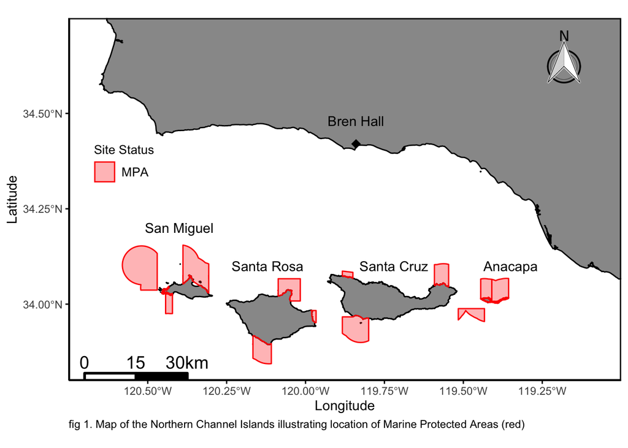

An array work has already been done analyzing the effects of MPA implementation on Kelp Forests (Hamilton & Caselle, 2015, Selden et al. 2017). It is well known that many trophic levels change in abundance whether in an MPA or in a fished area (A Decade of Protection, PISCO). It is also well know that Purple urchins can form “barrens” when densities reach a critical threshold (Ling et al., 2015). There is a tipping point where a phase-shift occurs from a macro-algae dominated system to an urchin barren (Dexter & Scheibling, 2014). The reef will become completely devoid of algae and the dominate space holder will be purple urchins(Ling et al., 2015, Dexter & Scheibling, 2014).

I began conducting sub-tidal surveys for PISCO in 2017 and have developed these questions based on anecdotal evidence. It was always visually evident if we were surveying in an MPA or reference site based on kelp and urchin densities. MPAs visually had more kelp and less urchins while reference sites visually had less kelp and more urchins.

In this study I will test my anecdotal questions with PISCO data. I ask the question; Do MPAs increase kelp densities and what invertebrate species inhibit kelp densities? I also take a simplistic approach and address the question; At what point do MPAs and reference sites kelp densities significantly differ following MPA implementation?

### Methods

In order to answer the desired questions I have obtained PISCO data running from 1999 to 2020. I have chosen to look at Anacapa Island, Santa Cruz Island, Santa Rosa Island, and San Miguel Island as those islands are the predominant data source for PISCO N. Channel Island survey sites (fig 1).

Data was collected through annual sub-tidal scuba surveys. 12 benthic transects (30 x 2 x 2 m) are surveyed at each site between June and August to quantify densities of invertebrates and macro-algae. Benthic surveys are stratified into three depth zones (approximately 5-, 10-, and 15-m depth). Giant kelp (Macrocystis pyrifera) (kelp) individuals greater than 1-m in height are counted and stipes are enumerated per individual and later summed at the transect level for analysis. Purple urchins (Strongylocentrotus purpuratus) greater than 2.5 cm in diameter are counted. Sites are either categorized as MPAs or reference sites, each MPA has a paired reference site.

Data was averaged to an annual site mean (n=658, MPA: n=310, Reference: n=348) for purple urchins and kelp stipes (kelp). Understory kelps and red urchins were not included as Giant kelp is the predominant structural species and red urchins are commercially fished.

All analysis was conducted in Rstudio and the code repository is linked (see supporting figures). OLS linear models and whelch two sample t tests ($\alpha$ < 0.05) were conducted based on previous studies understandings of affects purple urchins can have on kelp densities when urchin populations are left unchecked. Response variables were log transformed in order to normalize distribution (see supporting figures). The QQplot is not linear and the residuals show potential heteroscedasticity, model results should guide further research (see supporting figures). All other tests of model fit did show potential for acceptable model choice.

### Results

Through initial data visualization, trends can be observed for kelp densities and urchin densities inside MPAs and reference sites (fig 2). It is apparent that urchin densities between MPAs and reference sites fluctuate and follow similar trends until 2014, in which urchin densities inside MPAs show considerably lower densities. A similar trend is observed for kelp densities in which densities fluctuate until 2013 and then began to diverge with higher densities inside the MPAs.

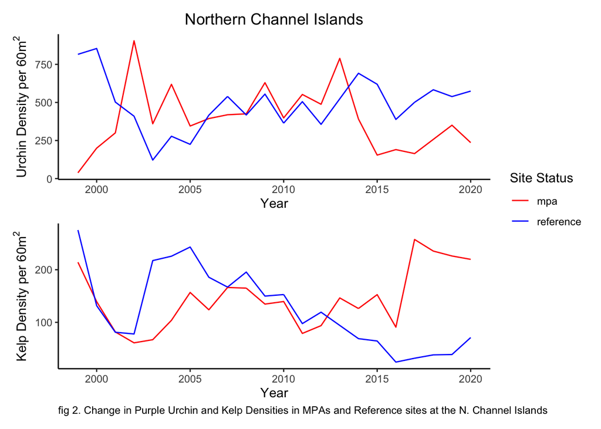

#### Linear Model

To determine what might be the cause of these differences of kelp densities in the MPAs and reference sites, a linear model was created ($\alpha$ < 0.05) (Tbl 1, fig 3). Annual site means for urchin densities, site status (MPA or Reference Site), and site status as an interaction with urchin densities, were all used as predictors for log kelp densities in the linear model. The results illustrate that urchin density is a significant predictor for log kelp densities (p<0.001). Interestingly site status is a poor predictor for log kelp densities (p=0.845) yet anecdotal observations say otherwise. The urchin density and site status interaction (p=0.095) was not found to be a significant interaction but can still indicate the affects that can occur between the two predictors. A negative trend can clearly be seen between log kelp density and urchin densities (fig 3). Overall model predictability is rather low (adjusted $R^{2}$ = 0.154) and not suited for predicting log kelp variability.

Tbl 1. Linear Model Results for Below Predictors

|  | log Kelp Density |  |  |
| --- | --- | --- | --- |
| Predictors | Estimates | Conf. Int (95%) | P-value |
| Intercept | 5.0113 | 4.8108 – 5.2119 | **<0.001** |
| Urchin Density | -0.0018 | -0.0022 – -0.0013 | **<0.001** |
| Site Status | 0.0280 | -0.2529 – 0.3088 | 0.845 |
| Urchin Density:Site Status | 0.0005 | -0.0001 – 0.0010 | 0.095 |
| Observations | 658 |  |  |
| R<sup>2</sup> / R<sup>2</sup> adjusted | 0.158 / 0.154 |  |  |

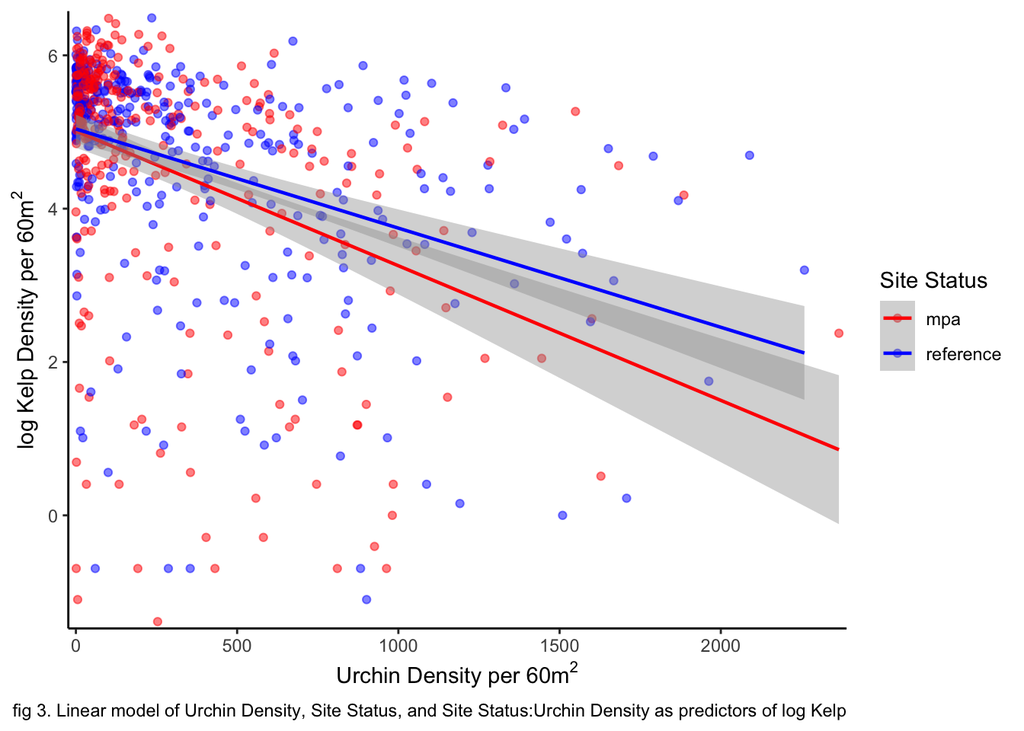

#### Welch Two Sample T Test

In order to test my anecdotal evidence of higher densities of kelp and lower densities of urchins in the MPAs and vice versa for reference sites, I have created a set of Welch Two Sample t-tests ($\alpha$ < 0.05).

The null hypothesis: There is no difference of kelp and urchin densities between MPAs and reference sites for the selected data set.

The alternative hypothesis: There is a difference in kelp and urchin densities between MPAs and reference sites for the selected data set.

Tbl 2. log Kelp Welch Two Sample t-test

[output not shown]

[figure not shown]

Tbl 3. log Urchin Welch Two Sample t-test

|  | log Urchin Density |  |  |
| --- | --- | --- | --- |
| Predictors | Estimates | Conf. Int (95%) | P-value |
| Site Status | -0.03 | -0.34 – 0.28 | 0.846 |

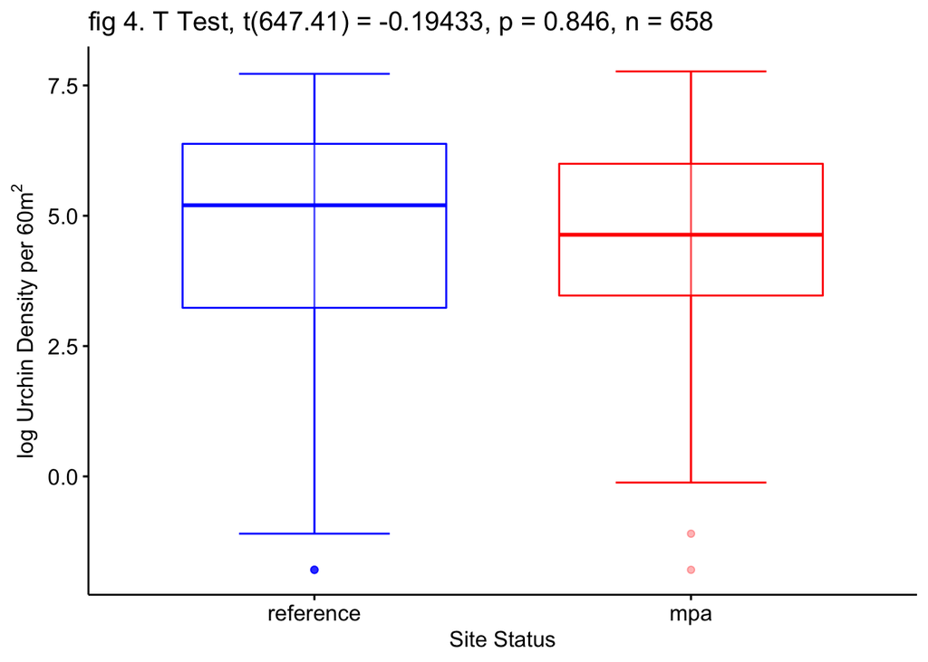

#### MPA Implementation Linear Model

In order to test the affects of time since MPA implementation on kelp densities both in MPAs and reference sites a linear model was created with time since MPA implementation as a predictor for log kelp densities (Tbl 4 & 5). A significant difference ($\alpha$ < 0.05) in kelp densities since the implementation of the MPAs occurred for years 15-18 (p=0.019, 0.012, 0.008, 0.01) after implementation or 2017-2020 (fig 6 Tbl 4).

A similar trend occurred for the reference sites. A significant difference in kelp densities since the implementation of MPAs occurred 12, 14-17 (p=0.001, <0.001, <0.001, 0.002, <0.001) years after implementation or 2014, 2016, 2017-2019.

Tbl 4 Linear model fit for change in MPA kelp density since implementation

|  | log Kelp Density |  |  |
| --- | --- | --- | --- |
| Predictors | Estimates | Conf. Int (95%) | P-value |
| Intercept | 3.86 | 2.90 – 4.81 | **<0.001** |
| 2 Years | 0.22 | -1.13 – 1.56 | 0.751 |
| 3 Years | 0.39 | -0.83 – 1.60 | 0.532 |
| 4 Years | 0.77 | -0.57 – 2.12 | 0.259 |
| 5 Years | 0.78 | -0.40 – 1.96 | 0.195 |
| 6 Years | 0.23 | -0.96 – 1.42 | 0.707 |
| 7 Years | 0.23 | -0.92 – 1.39 | 0.690 |
| 8 Years | 0.88 | -0.37 – 2.12 | 0.166 |
| 9 Years | -0.06 | -1.33 – 1.22 | 0.931 |
| 10 Years | 0.36 | -0.93 – 1.66 | 0.583 |
| 11 Years | 0.45 | -0.92 – 1.83 | 0.518 |
| 12 Years | 0.25 | -0.98 – 1.48 | 0.691 |
| 13 Years | 0.88 | -0.37 – 2.14 | 0.168 |
| 14 Years | -0.26 | -1.52 – 0.99 | 0.680 |
| 15 Years | 1.49 | 0.25 – 2.73 | **0.019** |
| 16 Years | 1.60 | 0.36 – 2.84 | **0.012** |
| 17 Years | 1.71 | 0.45 – 2.96 | **0.008** |
| 18 Years | 1.67 | 0.41 – 2.92 | **0.010** |
| Observations | 296 |  |  |
| R<sup>2</sup> / R<sup>2</sup> adjusted | 0.120 / 0.066 |  |  |

Tbl 5. Linear model fit for change in reference site kelp density since implementation

|  | log Kelp Density |  |  |
| --- | --- | --- | --- |
| Predictors | Estimates | Conf. Int (95%) | P-value |
| Intercept | 5.03 | 4.36 – 5.70 | **<0.001** |
| 2 Years | 0.54 | -0.34 – 1.43 | 0.228 |
| 3 Years | 0.39 | -0.48 – 1.26 | 0.377 |
| 4 Years | 0.07 | -0.82 – 0.95 | 0.880 |
| 5 Years | 0.23 | -0.58 – 1.03 | 0.577 |
| 6 Years | 0.04 | -0.77 – 0.85 | 0.929 |
| 7 Years | 0.05 | -0.75 – 0.85 | 0.907 |
| 8 Years | -0.21 | -1.03 – 0.61 | 0.614 |
| 9 Years | -0.65 | -1.48 – 0.19 | 0.127 |
| 10 Years | -0.34 | -1.18 – 0.50 | 0.429 |
| 12 Years | -1.50 | -2.39 – -0.62 | **0.001** |
| 13 Years | -0.99 | -1.99 – 0.00 | 0.051 |
| 14 Years | -2.23 | -3.20 – -1.26 | **<0.001** |
| 15 Years | -2.10 | -3.05 – -1.14 | **<0.001** |
| 16 Years | -1.47 | -2.39 – -0.55 | **0.002** |
| 17 Years | -1.71 | -2.63 – -0.78 | **<0.001** |
| 18 Years | -0.83 | -1.80 – 0.14 | 0.094 |
| Observations | 332 |  |  |
| R<sup>2</sup> / R<sup>2</sup> adjusted | 0.303 / 0.267 |  |  |

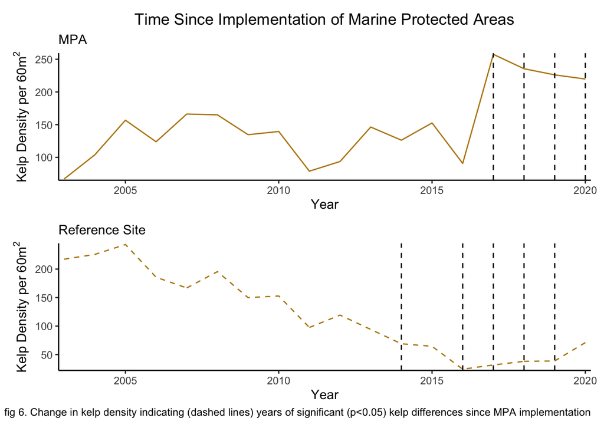

### Discussion

Understanding the changes that occur from the implementation of MPAs is important so we can know if they are working and benefiting the ecosystem. Through long term monitoring and analysis we can better understand how they evolve through time and this knowledge can then be translated across regions and systems for the implementation of new MPAs or reserves.

From these results we can see changes in kelp densities from the implementation of MPAs are not explicitly evident (fig 2). Kelp forests are highly dynamic ecosystems and fluctuations caused through environmental changes can lead to challenges in understanding changes through time (fig 2) (Reed et al. 2014). However from our linear models there does seem to be strong evidence of a negative relationship between urchin densities and kelp densities (fig 3 Tbl 1). This significant result ($\alpha$ < 0.05) does line up with my own anecdotal evidence of survey sites with high urchin densities and low kelp density or vice versa. Interestingly, I did not see any evidence for site status to significantlly affect either kelp or urchin densities (fig 3, 4, 5 Tbl 1,2,3). However, based on the long-run trends of urchin and kelp densities this makes sense why the tests I conducted did not pick up a difference (fig 2). There was a long period of time, many data points, where kelp densities did not significantly differ between MPAs and reference sites (fig 6 Tbl 4,5). The time period at which kelp densities began to significantly differ between MPAs and reference sites coincides with my own anecdotal observations beginning in 2017 (fig 6, Tbl 4,5) as that is when I began conducting surveys for PISCO.

Now the real question lies with in, what happened in the year 2013-2014 at the N. Channel Islands that caused such sudden changes in kelp and urchin densities inside MPAs and reference sites (fig 2)? Further research needs to be conducted but evidence supports that the mass sea star war wasting event that proliferated from Baja to Alaska affected kelp densities (Eisaguirre et al., 2020). The sunflower star (Pycnopodia helianthordes), a keystone species, consumes urchins but was functionally extirpated from the N. Channel Islands by 2014 due to sea star wasting disease (Eisaguirre et al., 2020, Hewson et al., 2018, Moitoza & Philips, 1979) . A change as abrupt and sudden as the loss of a keystone species can cause shifts in any ecosystem. Especially if a site (IE reference site) is heavily fished, thus decreasing the remaining urchin predator guild, and ultimately leading to an explosion of urchins with a dramatic loss of kelp (Eisaguirre et al., 2020). However if a site is protected, the release of fishing pressure can lead to increased resilience in the system due to the remaining urchin predator guild mediating urchin levels and allowing for kelp’s to persist (Eisaguirre et al., 2020).

### Conclusion

Further research needs to be conducted, however this study lends support to the importance of maintaining urchin populations in order for healthy kelp forests to persist. Along with the idea that kelps in marine protected areas could possibly withstand a greater degree of perturbations supporting the already hypothesized theory that MPAs increase ecosystem resilience.

### References

- Channel Keeper. “About the Santa Barbara Channel.” About the Santa Barbara Channel, November 27, 2021. https://www.sbck.org/about-us/about-the-santa-barbara-channel/.
- Eisaguirre, Jacob H., Joseph M.Eisaguirre, Kathryn Davis, Peter M. Carlson, Steven D. Gaines, and Jennifer E. Caselle. “Trophic Redundancy and Predator Size Class Structure Drive Differences in Kelp Forest Ecosystem Dynamics.” *Ecology* 101, no. 5 (2020): e02993. https://doi.org/10.1002/ecy.2993.
- Filbee-Dexter, K, and Re Scheibling. “Sea Urchin Barrens as Alternative Stable States of Collapsed Kelp Ecosystems.” *Marine Ecology Progress Series* 495 (January 9, 2014): 1–25. https://doi.org/10.3354/meps10573.
- Hamilton, Scott L., and Jennifer E. Caselle. “Exploitation and Recovery of a Sea Urchin Predator Has Implications for the Resilience of Southern California Kelp Forests.” *Proceedings of the Royal Society B: Biological Sciences* 282, no. 1799 (January 22, 2015): 20141817. https://doi.org/10.1098/rspb.2014.1817.
- Hewson, Ian, Kalia S. I. Bistolas, Eva M. Quijano Cardé, Jason B. Button, Parker J. Foster, Jacob M. Flanzenbaum, Jan Kocian, and Chaunte K. Lewis. “Investigating the Complex Association Between Viral Ecology, Environment, and Northeast Pacific Sea Star Wasting.” *Frontiers in Marine Science* 5 (2018): 77. https://doi.org/10.3389/fmars.2018.00077.
- Ling, S. D., R. E. Scheibling, A. Rassweiler, C. R. Johnson, N. Shears, S. D. Connell, A. K. Salomon, et al. “Global Regime Shift Dynamics of Catastrophic Sea Urchin Overgrazing.” *Philosophical Transactions of the Royal Society B: Biological Sciences* 370, no. 1659 (January 5, 2015): 20130269. https://doi.org/10.1098/rstb.2013.0269.
- Moitoza, D. J., and D. W. Phillips. “Prey Defense, Predator Preference, and Nonrandom Diet: The Interactions between Pycnopodia Helianthoides and Two Species of Sea Urchins.” *Marine Biology* 53, no. 4 (August 1, 1979): 299–304. https://doi.org/10.1007/BF00391611.
- “Prey Defense, Predator Preference, and Nonrandom Diet: The Interactions between Pycnopodia Helianthoides and Two Species of Sea Urchins.” *Marine Biology* 53, no. 4 (August 1, 1979): 299–304. https://doi.org/10.1007/BF00391611.
- Reed, Daniel C., Andrew R. Rassweiler, Robert J. Miller, Henry M. Page, Sally J. Holbrook, Daniel C. Reed, Andrew R. Rassweiler, Robert J. Miller, Henry M. Page, and Sally J. Holbrook. “The Value of a Broad Temporal and Spatial Perspective in Understanding Dynamics of Kelp Forest Ecosystems.” *Marine and Freshwater Research* 67, no. 1 (July 6, 2015): 14–24. https://doi.org/10.1071/MF14158.
- Selden, Rebecca L., Steven D. Gaines, Scott L. Hamilton, and Robert R. Warner. “Protection of Large Predators in a Marine Reserve Alters Size-Dependent Prey Mortality.” *Proceedings of the Royal Society B: Biological Sciences* 284, no. 1847 (January 25, 2017): 20161936. https://doi.org/10.1098/rspb.2016.1936.
- “Marine Protected Areas - Channel Islands National Park (U.S. National Park Service).” National Park Service. Accessed November 27, 2021. https://www.nps.gov/chis/learn/nature/marine-protected-areas.htm.

### GitHub Repository: https://github.com/Jake-Eisaguirre/Final_Project

### Supporting Figures

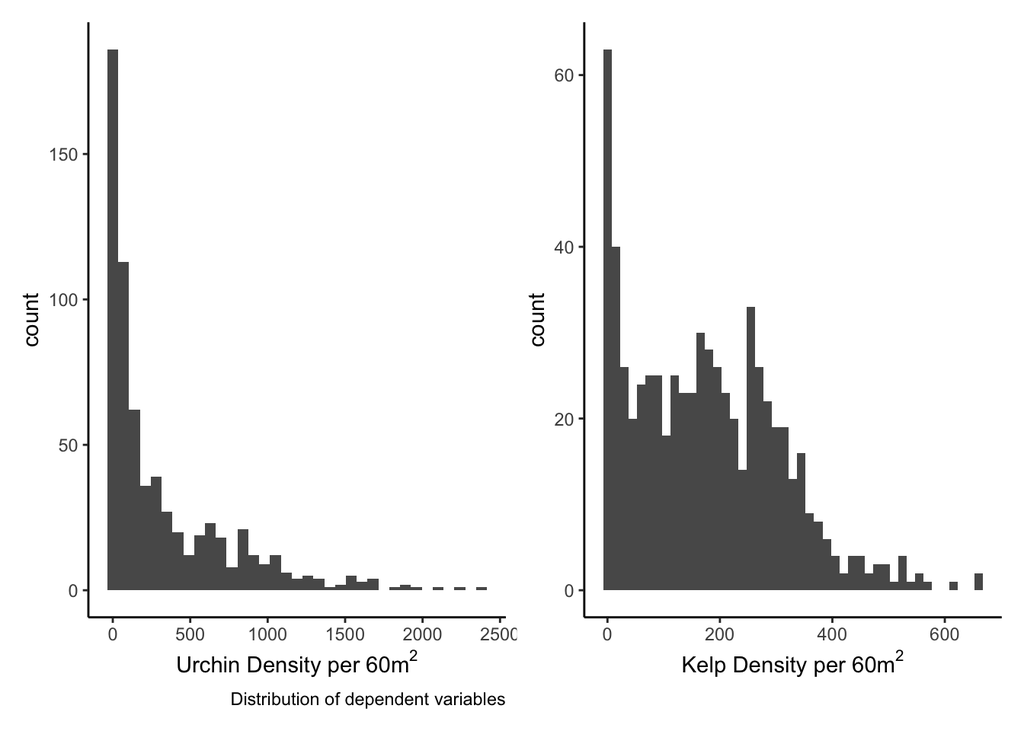

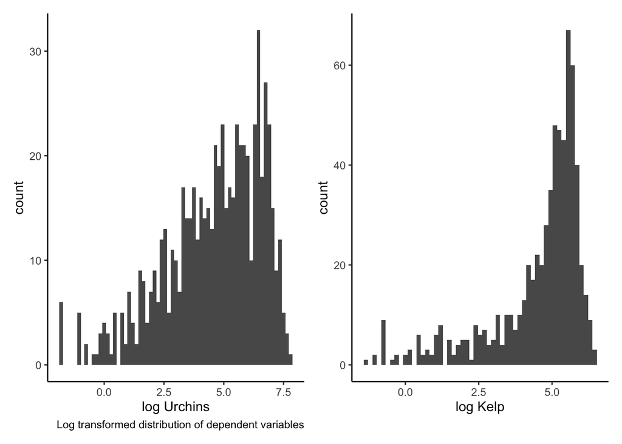

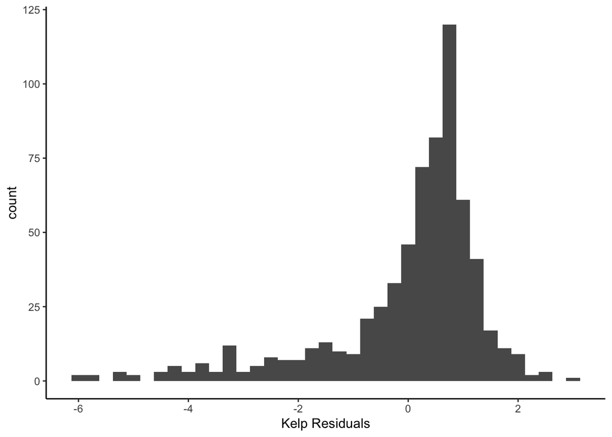

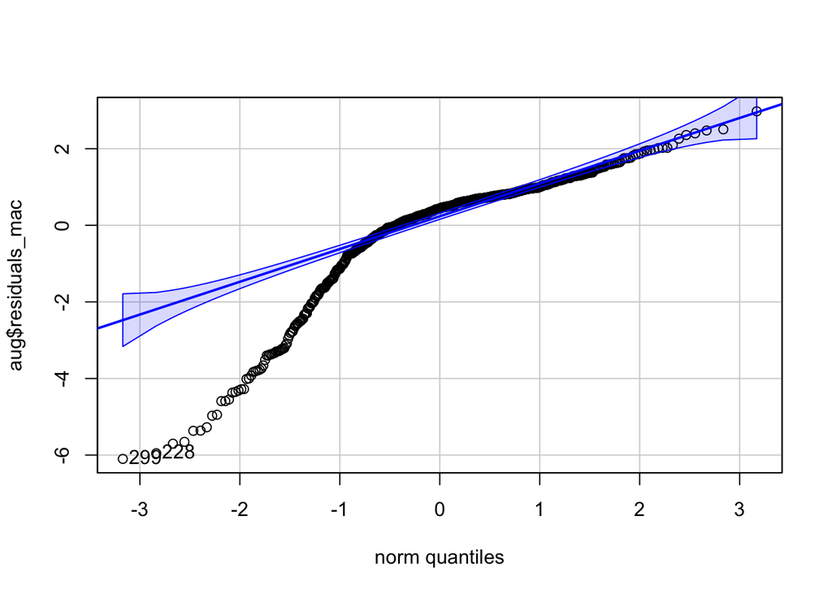

```
## [1] 299 228
```

```
## [1] "mean residuals -2.19943444182886e-15"
```

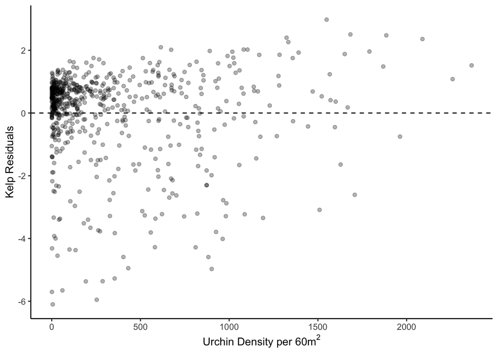